# Stat 361 — Recitation2

Probability Distributions in R

Serenay Çakar

2026-02-26

📘 **About These Notes**  
These notes cover sampling from finite populations, the theory and R implementation of major **continuous** and **discrete probability distributions**, and how to build **custom R functions** that compute and plot PDFs, PMFs, and CDFs.

# Sampling from a Finite Population

## The `sample()` Function

The `sample()` function is the foundation of simulation in R. Its four key arguments are given in the following table.

Arguments of the `sample()` function

| Argument | Description |
| --- | --- |
| `x` | Vector of possible values to draw from (e.g., `1:6` for a die, `c('H','T')` for a coin). |
| `size` | How many values to draw. Defaults to `length(x)` if omitted. |
| `replace` | Logical. `FALSE` = without replacement (default); `TRUE` = with replacement. |
| `prob` | Optional probability weights, one per element of `x`. Must sum to 1. |

## Worked Examples — `sample()`

- Draw 30 integers from 1:7 WITH replacement

```r
sample(1:7, size = 30, replace = TRUE)
```

```
#>  [1] 4 2 7 4 4 2 7 3 3 5 5 6 1 4 3 6 7 2 1 6 3 6 6 7 1 6 6 6 1 3
```

- Draw 3 integers from 1:7 WITHOUT replacement

```r
sample(1:7, size = 3, replace = FALSE)
```

```
#> [1] 2 1 6
```

- Simulate 10 flips of a FAIR coin

```r
set.seed(361)
sample(x = c("H", "T"), size = 10, replace = TRUE)
```

```
#>  [1] "T" "H" "T" "H" "H" "H" "H" "T" "H" "T"
```

- Simulate 10 flips of a BIASED coin: P(H)=0.8, P(T)=0.2

```r
set.seed(361)
sample(x       = c("H", "T"),
       prob    = c(0.8, 0.2),
       size    = 10,
       replace = TRUE)
```

```
#>  [1] "H" "H" "H" "H" "H" "H" "H" "H" "H" "H"
```

**Exercise — Treasure Chest Simulation**

A treasure chest holds 100 coins: 20 gold, 30 silver, and 50 bronze. Randomly draw 10 coins (without replacement) and report how many of each type you drew. Repeat 1000 times and compute the average number of each coin type drawn.

```r
# Set up the chest
chest <- c(rep("gold", 20), rep("silver", 30), rep("bronze", 50))

# Single draw
set.seed(42)
draw <- sample(chest, size = 10, replace = FALSE)
table(draw)
```

```
#> draw
#> bronze   gold silver
#>      5      1      4
```

```r
# Replicate 1000 times and summarise
set.seed(42)
results <- replicate(1000, {
  d <- sample(chest, size = 10, replace = FALSE)
  c(gold   = sum(d == "gold"),
    silver = sum(d == "silver"),
    bronze = sum(d == "bronze"))
})

round(rowMeans(results), 3)   # average counts across 1000 draws
```

```
#>   gold silver bronze
#>  2.037  3.022  4.941
```

```r
# alternatively
set.seed(42)

results <- matrix(NA, nrow = 3, ncol = 1000)
rownames(results) <- c("gold", "silver", "bronze")

for(i in 1:1000){
  d <- sample(chest, size = 10, replace = FALSE)
  results[, i] <- c(
    gold   = sum(d == "gold"),
    silver = sum(d == "silver"),
    bronze = sum(d == "bronze")
  )
}

round(rowMeans(results), 3)
```

```
#>   gold silver bronze
#>  2.037  3.022  4.941
```

# R Functions for Probability Distributions

## The Four-Prefix System

For every distribution `dist` in R, there are four functions:

| Prefix | Function | Returns |
| --- | --- | --- |
| `d` | `ddist(x, ...)` | **Density** (PDF) or **probability mass** (PMF) at `x` |
| `p` | `pdist(x, ...)` | **CDF** — P(X ≤ x) |
| `q` | `qdist(p, ...)` | **Quantile** — value x such that P(X ≤ x) = p |
| `r` | `rdist(n, ...)` | **Random sample** of size n |

```r
# Normal distribution, four prefixes:
dnorm(0, mean = 0, sd = 1)          # PDF at x=0  → 0.3989
```

```
#> [1] 0.3989423
```

```r
pnorm(1.96, mean = 0, sd = 1)       # P(Z ≤ 1.96) → ≈ 0.975
```

```
#> [1] 0.9750021
```

```r
qnorm(0.975, mean = 0, sd = 1)      # 97.5th quantile → ≈ 1.96
```

```
#> [1] 1.959964
```

```r
set.seed(1); rnorm(5, mean = 0, sd = 1)  # 5 random draws
```

```
#> [1] -0.6264538  0.1836433 -0.8356286  1.5952808  0.3295078
```

# Continuous Distributions

## 1. Uniform Distribution U(a, b)

**Definition:** All outcomes in the interval $[a, b]$ are equally likely.

$$f(x) = \frac{1}{b-a}, \quad a \leq x
\leq b$$

$$F(x) = \frac{x - a}{b - a}, \quad a \leq
x \leq b$$

**Mean:** $\dfrac{a+b}{2}$ **Variance:** $\dfrac{(b-a)^2}{12}$

### Function: Plot Uniform PDF and CDF

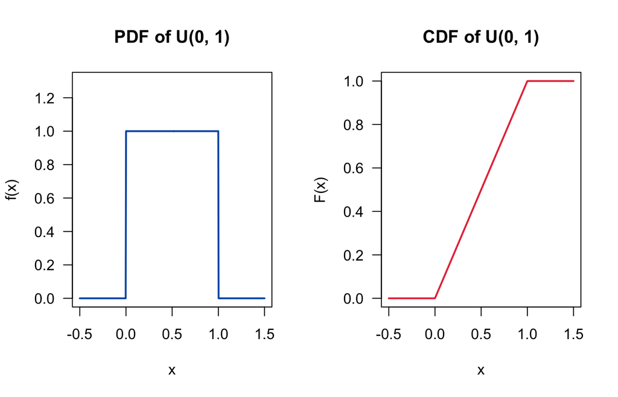

```r
plot_uniform <- function(a = 0, b = 1) {
  x   <- seq(a - 0.5*(b-a), b + 0.5*(b-a), length.out = 500) # It extends the plotting window by half the interval length on each side.
  pdf <- dunif(x, min = a, max = b)
  cdf <- punif(x, min = a, max = b)

  par(mfrow = c(1, 2))

  # PDF
  plot(x, pdf, type = "l", lwd = 2, col = "#0059b3",
       ylim = c(0, max(pdf) * 1.3),
       main = sprintf("PDF of U(%s, %s)", a, b),
       xlab = "x", ylab = "f(x)", las = 1)

  # CDF
  plot(x, cdf, type = "l", lwd = 2, col = "#e63946",
       main = sprintf("CDF of U(%s, %s)", a, b),
       xlab = "x", ylab = "F(x)", las = 1)

  par(mfrow = c(1, 1))
}

plot_uniform(0, 1)
```

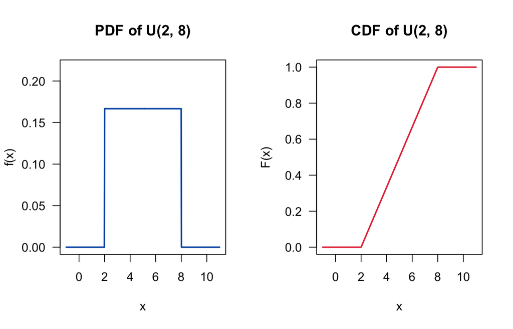

```r
plot_uniform(2, 8)   # Please try different bounds
```

*`sprintf()`* means string print formatted.

General syntax:

`sprintf("format text", values)`

It inserts values into placeholders inside a string.

- %s is a placeholder
- %s means: “insert something as a string”
- The first %s is replaced by a, and the second %s is replaced by b.

### Function: Uniform Statistics

```
#> U(0, 1) with n = 5000
#> Theoretical mean     : 0.500
#> Sample mean          : 0.503
#> Theoretical variance : 0.083
#> Sample variance      : 0.085
```

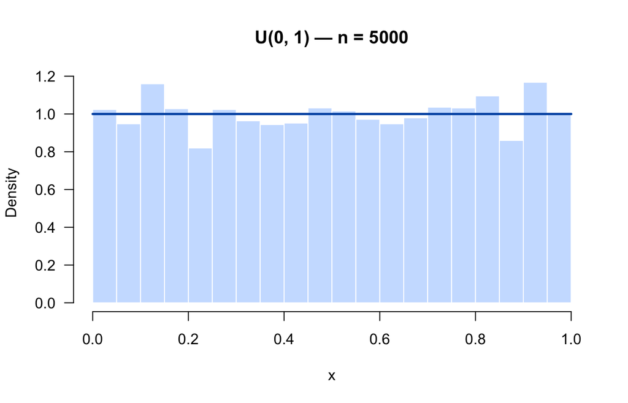

```r
uniform_stats <- function(a = 0, b = 1, n = 5000, seed = 42) {

  set.seed(seed)
  x <- runif(n, min = a, max = b)

  theory_mean <- (a + b) / 2
  theory_var  <- (b - a)^2 / 12

  cat(sprintf("U(%s, %s) with n = %s\n", a, b, n))
  cat(sprintf("Theoretical mean     : %.3f\n", theory_mean))
  cat(sprintf("Sample mean          : %.3f\n", mean(x)))
  cat(sprintf("Theoretical variance : %.3f\n", theory_var))
  cat(sprintf("Sample variance      : %.3f\n\n", var(x)))

  hist(x, freq = FALSE,
       col = "#cce0ff", border = "white", breaks = 30,
       main = sprintf("U(%s, %s) — n = %s", a, b, n),
       xlab = "x", las = 1)

  curve(dunif(x, a, b), add = TRUE, col = "#0059b3", lwd = 2.5)
}

uniform_stats(0, 1, n = 5000)
```

```r
uniform_stats(2, 8, n = 5000)
```

```
#> U(2, 8) with n = 5000
#> Theoretical mean     : 5.000
#> Sample mean          : 5.019
#> Theoretical variance : 3.000
#> Sample variance      : 3.050
```

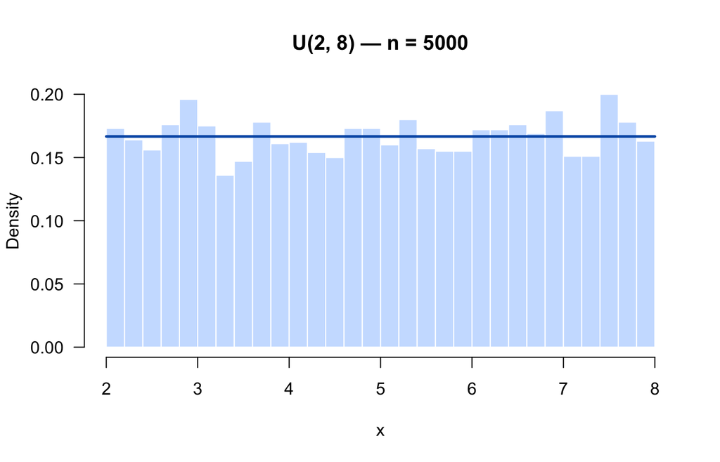

**Question U-1:** Write a function `runif_prob(a, b, lo, hi)` that generates 10,000 samples from U(a,b) and estimates P(lo ≤ X ≤ hi) empirically. Compare your estimate with the theoretical value `(hi - lo)/(b - a)`.

```r
runif_prob <- function(a, b, lo, hi, n = 10000, seed = 1) {
  set.seed(seed)
  x        <- runif(n, a, b)
  emp      <- mean(x >= lo & x <= hi)
  theory   <- (hi - lo) / (b - a)
  cat(sprintf("P(%.1f ≤ X ≤ %.1f) — Theoretical: %.4f  |  Empirical: %.4f\n",
              lo, hi, theory, emp))
}

runif_prob(0, 10, 2, 7)
```

```
#> P(2.0 ≤ X ≤ 7.0) — Theoretical: 0.5000  |  Empirical: 0.4952
```

```r
runif_prob(0, 1,  0.3, 0.8)
```

```
#> P(0.3 ≤ X ≤ 0.8) — Theoretical: 0.5000  |  Empirical: 0.4912
```

## 2. Normal Distribution N(μ, σ²)

$$f(x) = \frac{1}{\sigma\sqrt{2\pi}}
\exp\!\left(-\frac{(x-\mu)^2}{2\sigma^2}\right), \quad -\infty < x
< \infty$$

**Mean:** $\mu$ **Variance:** $\sigma^2$

### Function: Plot Normal PDF and CDF

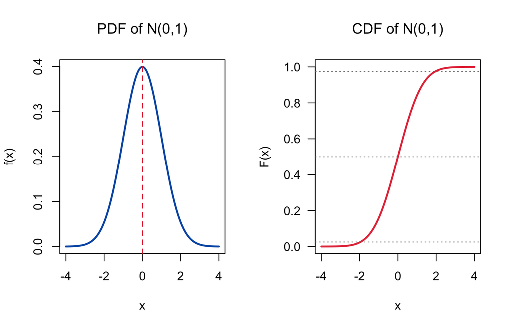

```r
plot_normal <- function(mu = 0, sigma = 1) {
  x   <- seq(mu - 4*sigma, mu + 4*sigma, length.out = 500)
  pdf <- dnorm(x, mean = mu, sd = sigma)
  cdf <- pnorm(x, mean = mu, sd = sigma)

  par(mfrow = c(1, 2))

   # PDF
  plot(x, pdf, type = "n",
       main = bquote("PDF of N(" * .(mu) * "," * .(sigma^2) * ")"),
       xlab = "x", ylab = "f(x)")
  lines(x, pdf, col = "#0059b3", lwd = 2.5)
  abline(v = mu, col = "#e63946", lty = 2, lwd = 1.5)

  # CDF
  plot(x, cdf, type = "l", col = "#e63946", lwd = 2.5,
       main = bquote("CDF of N(" * .(mu) * "," * .(sigma^2) * ")"),
       xlab = "x", ylab = "F(x)", las = 1)
  abline(h = c(0.025, 0.5, 0.975), lty = 3, col = "grey50")

  par(mfrow = c(1, 1))
}

plot_normal(0, 1)
```

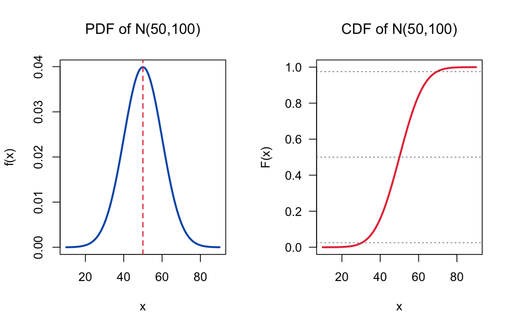

```r
plot_normal(50, 10)
```

**`bquote()`** is used in R to create mathematical expressions that contain variable values.

It allows you to:

- Write math-style notation (like N(μ, σ²)).
- Insert actual numeric values into that notation.

Inside plotmath expressions:

```r
"A" * B
```

means:

Put A and B next to each other.

### Function: Normal Tail Probabilities

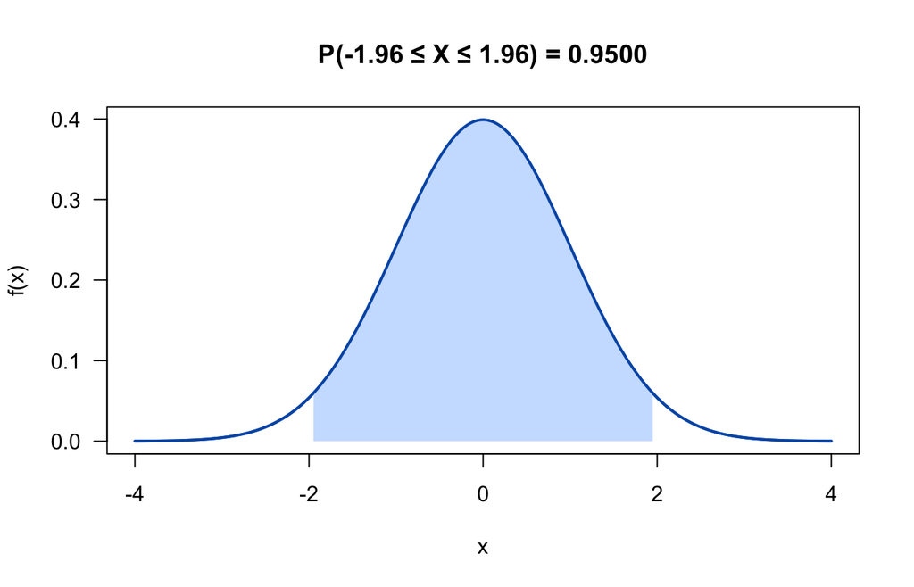

```r
normal_area <- function(mu = 0, sigma = 1, lo = -Inf, hi = Inf) {
  prob <- pnorm(hi, mu, sigma) - pnorm(lo, mu, sigma)

  x   <- seq(mu - 4*sigma, mu + 4*sigma, length.out = 500)
  pdf <- dnorm(x, mu, sigma)

  plot(x, pdf, type = "l", lwd = 2, col = "#0059b3",
       main = sprintf("P(%.2f ≤ X ≤ %.2f) = %.4f", lo, hi, prob),
       xlab = "x", ylab = "f(x)", las = 1)

  shade <- x >= max(lo, min(x)) & x <= min(hi, max(x))
  polygon(c(x[shade][1], x[shade], tail(x[shade],1)),
          c(0, pdf[shade], 0), col = "#cce0ff", border = NA)
  lines(x, pdf, lwd = 2, col = "#0059b3")

}

normal_area(0, 1, lo = -1.96, hi = 1.96)   # ≈ 0.95
```

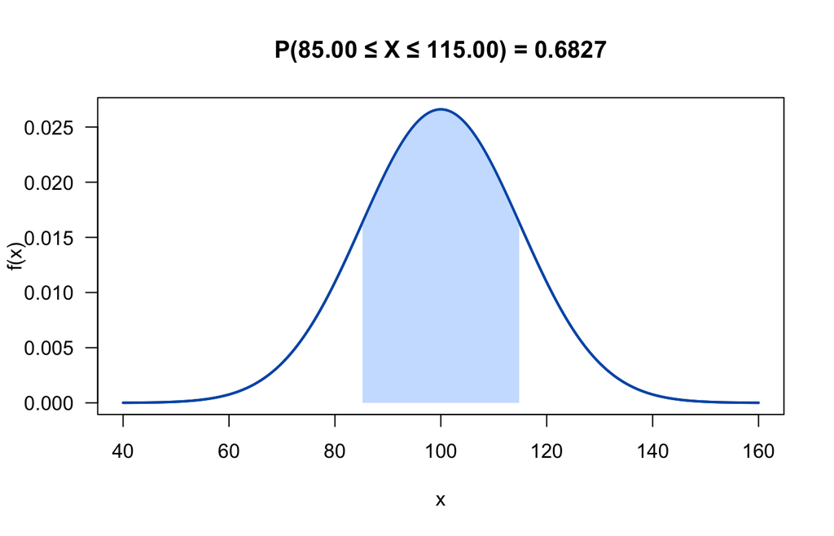

```r
normal_area(100, 15, lo = 85, hi = 115)    # IQ ± 1σ
```

### Function: Compare Multiple Normal Curves

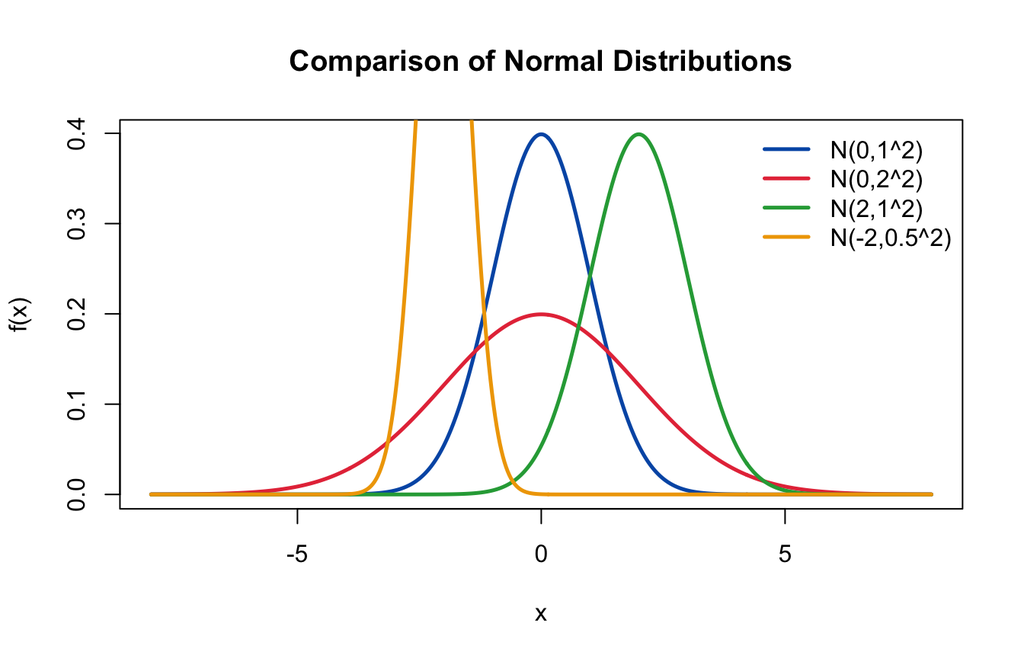

```r
compare_normals <- function(params_list) {

  colors <- c("#0059b3","#e63946","#28a745","#f0a500","#8e44ad")

  # Convert list to matrix (each row: mu, sigma)
  params <- do.call(rbind, params_list)

  # Define common x-range
  x_min <- min(params[,1] - 4 * params[,2])
  x_max <- max(params[,1] + 4 * params[,2])
  x <- seq(x_min, x_max, length.out = 500)

  # Plot first curve (sets axes automatically)
  plot(x, dnorm(x, params[1,1], params[1,2]),
       type = "l",
       col = colors[1],
       lwd = 2.5,
       main = "Comparison of Normal Distributions",
       xlab = "x", ylab = "f(x)")

  # Add remaining curves
  for (i in 2:nrow(params)) {
    lines(x, dnorm(x, params[i,1], params[i,2]),
          col = colors[i], lwd = 2.5)
  }

  # Legend
  legend("topright",
         legend = paste("N(", params[,1], ",", params[,2], "^2)", sep=""),
         col = colors[1:nrow(params)],
         lwd = 2.5, bty = "n")
}

compare_normals(list(c(0,1), c(0,2), c(2,1), c(-2, 0.5)))
```

**Question N-1:** The heights of adult males are normally distributed with μ = 175 cm and σ = 7 cm.

1. What proportion of males are taller than 185 cm?
2. What height marks the 95th percentile?
3. Generate 1,000 samples and plot a histogram with the theoretical PDF overlay.

```r
mu <- 175; sigma <- 7

# a. P(X > 185)
p_above_185 <- 1 - pnorm(185, mu, sigma)
cat(sprintf("P(X > 185) = %.4f  (%.1f%%)\n", p_above_185, p_above_185*100))
```

```
#> P(X > 185) = 0.0766  (7.7%)
```

```r
# b. 95th percentile
p95 <- qnorm(0.95, mu, sigma)
cat(sprintf("95th percentile height = %.2f cm\n", p95))
```

```
#> 95th percentile height = 186.51 cm
```

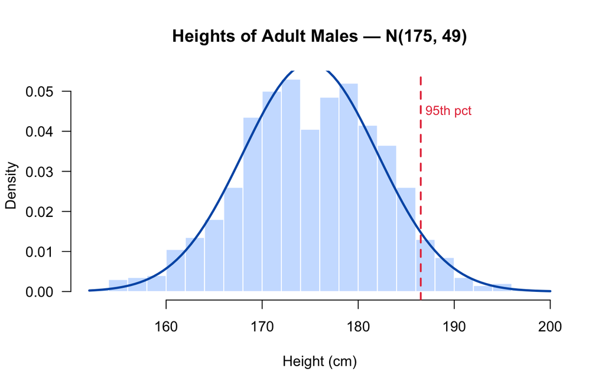

```r
# c. Histogram + theoretical PDF
set.seed(361)
heights <- rnorm(1000, mu, sigma)

hist(heights, freq = FALSE, breaks = 25,
     col = "#cce0ff", border = "white",
     main = "Heights of Adult Males — N(175, 49)",
     xlab = "Height (cm)", las = 1)
curve(dnorm(x, mu, sigma), add = TRUE, col = "#0059b3", lwd = 2.5)
abline(v = p95, col = "#e63946", lty = 2, lwd = 2)
text(p95 + 0.5, 0.045, "95th pct", col = "#e63946", adj = 0, cex = 0.9)
```

**Question N-2:** The Empirical Rule. Using R, verify that for N(μ, σ²):

- P(μ − σ ≤ X ≤ μ + σ) ≈ 68.27%
- P(μ − 2σ ≤ X ≤ μ + 2σ) ≈ 95.45%
- P(μ − 3σ ≤ X ≤ μ + 3σ) ≈ 99.73%

```r
empirical_rule <- function(mu = 0, sigma = 1) {
  k_vals <- 1:3
  probs  <- sapply(k_vals, function(k)
    pnorm(mu + k*sigma, mu, sigma) - pnorm(mu - k*sigma, mu, sigma))

  data.frame(
    `±k σ`        = paste0("±", k_vals, "σ"),
    `Theoretical`  = c("68.27%", "95.45%", "99.73%"),
    `Computed`     = paste0(round(probs * 100, 4), "%"),
    check.names    = FALSE
  )
}

empirical_rule(mu = 100, sigma = 15)
```

| ±k σ | Theoretical | Computed |
| --- | --- | --- |
| ±1σ | 68.27% | 68.2689% |
| ±2σ | 95.45% | 95.45% |
| ±3σ | 99.73% | 99.73% |

## 3. Exponential Distribution Exp(λ)

Models the **time between events** in a Poisson process with rate λ.

$$f(x) = \lambda e^{-\lambda x}, \quad x
\geq 0$$

$$F(x) = 1 - e^{-\lambda x}$$

**Mean:** $\dfrac{1}{\lambda}$ **Variance:** $\dfrac{1}{\lambda^2}$ **Memoryless property:** $P(X > s+t \mid X > s) = P(X > t)$

### Function: Plot Exponential for Multiple Rates

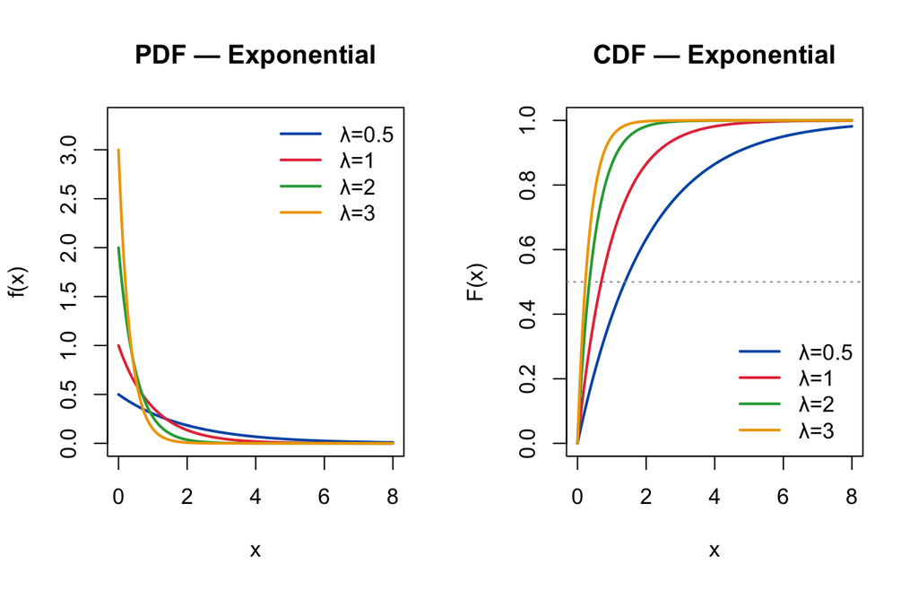

```r
plot_exponential <- function(lambdas = c(0.5, 1, 2)) {
  colors <- c("#0059b3", "#e63946", "#28a745", "#f0a500")
  x <- seq(0, 8, length.out = 500)

  par(mfrow = c(1, 2))  # side-by-side plots

  # PDF
  plot(x, dexp(x, lambdas[1]), type = "n",
       ylim = c(0, max(lambdas) * 1.1),
       main = "PDF — Exponential", xlab = "x", ylab = "f(x)")
  for (i in seq_along(lambdas)) lines(x, dexp(x, lambdas[i]), col = colors[i], lwd = 2)
  legend("topright", legend = paste0("λ=", lambdas), col = colors[seq_along(lambdas)], lwd = 2, bty = "n")

  # CDF
  plot(x, pexp(x, lambdas[1]), type = "n",
       ylim = c(0, 1),
       main = "CDF — Exponential", xlab = "x", ylab = "F(x)")
  for (i in seq_along(lambdas)) lines(x, pexp(x, lambdas[i]), col = colors[i], lwd = 2)
  abline(h = 0.5, col = "grey60", lty = 3)
  legend("bottomright", legend = paste0("λ=", lambdas), col = colors[seq_along(lambdas)], lwd = 2, bty = "n")

  par(mfrow = c(1, 1))
}

plot_exponential(c(0.5, 1, 2, 3))
```

**Question E-1:** Customer service calls arrive at a rate of λ = 3 calls per hour.

1. What is the probability that the **next call arrives within 10 minutes**?
2. What is the probability of waiting **more than 30 minutes** for a call?
3. Find the **median waiting time**.

```r
lambda <- 3   # calls per hour

# a. P(X <= 10 min = 10/60 hours)
p_10min <- pexp(10/60, rate = lambda)
cat(sprintf("a. P(next call ≤ 10 min) = %.4f\n", p_10min))
```

```
#> a. P(next call ≤ 10 min) = 0.3935
```

```r
# b. P(X > 30 min = 0.5 hours)
p_30min <- 1 - pexp(0.5, rate = lambda)
cat(sprintf("b. P(wait > 30 min)      = %.4f\n", p_30min))
```

```
#> b. P(wait > 30 min)      = 0.2231
```

```r
# c. Median = log(2)/lambda
median_time <- qexp(0.5, rate = lambda)
cat(sprintf("c. Median wait time      = %.4f hours = %.1f min\n",
            median_time, median_time * 60))
```

```
#> c. Median wait time      = 0.2310 hours = 13.9 min
```

## 4. Gamma Distribution Gamma(k, θ)

$$f(x; k, \theta) = \frac{x^{k-1}
e^{-x/\theta}}{\theta^k \,\Gamma(k)}, \quad x > 0$$

- $k$: **shape** parameter $\theta$: **scale** parameter
- **Mean:** $k\theta$ **Variance:** $k\theta^2$
- Special cases: Exp(λ) = Gamma(1, 1/λ); Chi-squared(ν) = Gamma(ν/2, 2)

### Function: Plot Gamma Families

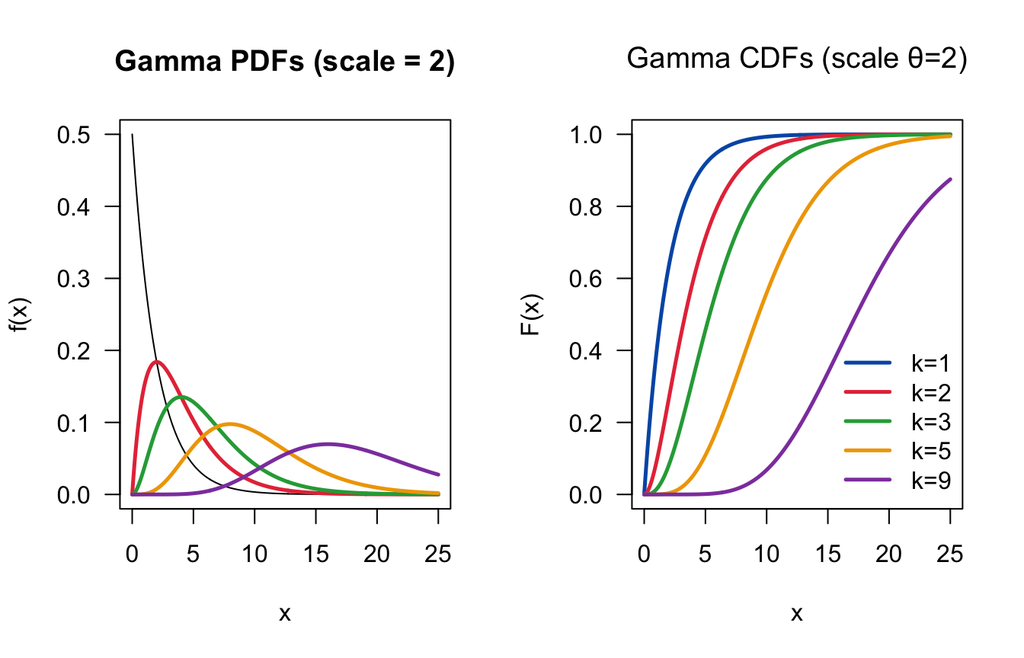

```r
plot_gamma_family <- function() {
  x      <- seq(0, 25, length.out = 500)
  shapes <- c(1, 2, 3, 5, 9)
  scale  <- 2
  colors <- c("#0059b3","#e63946","#28a745","#f0a500","#8e44ad")

  par(mfrow = c(1, 2))

  # PDF
  plot(x, dgamma(x, shape = shapes[1], scale = scale),
     type = "l",
     main = sprintf("Gamma PDFs (scale = %s)", scale),
     xlab = "x", ylab = "f(x)", las = 1)

for (i in 2:length(shapes)) {
  lines(x, dgamma(x, shape = shapes[i], scale = scale),
        col = colors[i], lwd = 2.5)
}

  # CDF
  plot(x, rep(0, 500), type = "n", ylim = c(0, 1),
       main = bquote("Gamma CDFs (scale θ=" * .(scale) * ")"),
       xlab = "x", ylab = "F(x)", las = 1)
  for (i in seq_along(shapes)) {
    lines(x, pgamma(x, shape = shapes[i], scale = scale),
          col = colors[i], lwd = 2.5)
  }
  legend("bottomright", legend = paste0("k=", shapes),
         col = colors, lwd = 2.5, bty = "n")

  par(mfrow = c(1, 1))
}

plot_gamma_family()
```

### Function: Gamma Goodness-of-Fit

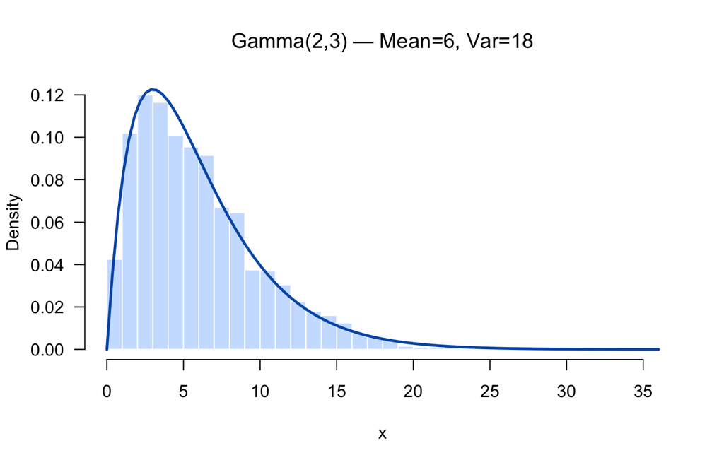

```
#> Theoretical: mean=6.00, var=18.00
#> Sample:      mean=6.04, var=17.42
```

```r
gamma_fit_check <- function(k = 3, theta = 2, n = 2000, seed = 7) {
  set.seed(seed)
  x <- rgamma(n, shape = k, scale = theta)

  hist(x, freq = FALSE, breaks = 35,
       col = "#cce0ff", border = "white",
       main = bquote("Gamma(" * .(k) * "," * .(theta) *
                     ") — Mean=" * .(k*theta) *
                     ", Var=" * .(k*theta^2)),
       xlab = "x", las = 1)
  curve(dgamma(x, shape = k, scale = theta),
        add = TRUE, col = "#0059b3", lwd = 2.5)

  cat(sprintf("Theoretical: mean=%.2f, var=%.2f\n", k*theta, k*theta^2))
  cat(sprintf("Sample:      mean=%.2f, var=%.2f\n", mean(x), var(x)))
}

gamma_fit_check(k = 2, theta = 3)
```

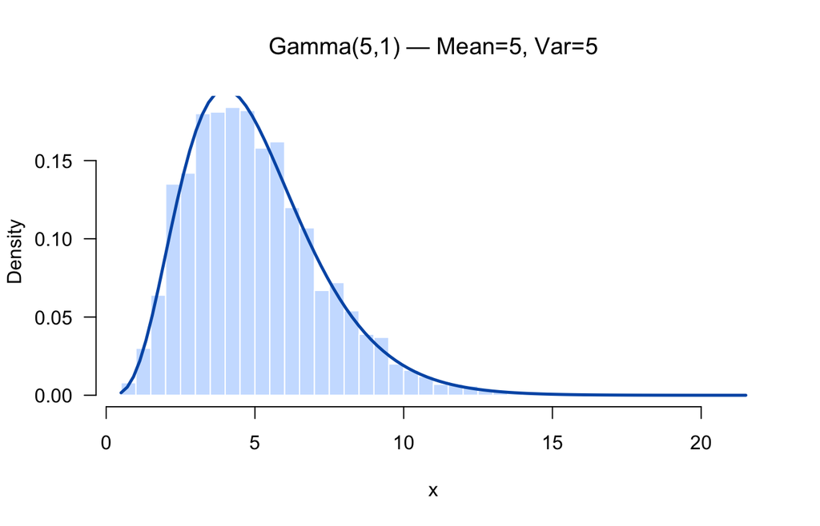

```
#> Theoretical: mean=5.00, var=5.00
#> Sample:      mean=5.02, var=5.13
```

```r
gamma_fit_check(k = 5, theta = 1)
```

**Question G-1:** The lifetime (in years) of a machine follows a Gamma(3, 2) distribution.

1. What is the probability the machine lasts **more than 10 years**?
2. What is the **median** lifetime?
3. Plot the PDF and mark the mean and median.

```r
k <- 3; theta <- 2

# a. P(X > 10)
p_above_10 <- 1 - pgamma(10, shape = k, scale = theta)
cat(sprintf("a. P(X > 10) = %.4f\n", p_above_10))
```

```
#> a. P(X > 10) = 0.1247
```

```r
# b. Median
med <- qgamma(0.5, shape = k, scale = theta)
cat(sprintf("b. Median    = %.4f years\n", med))
```

```
#> b. Median    = 5.3481 years
```

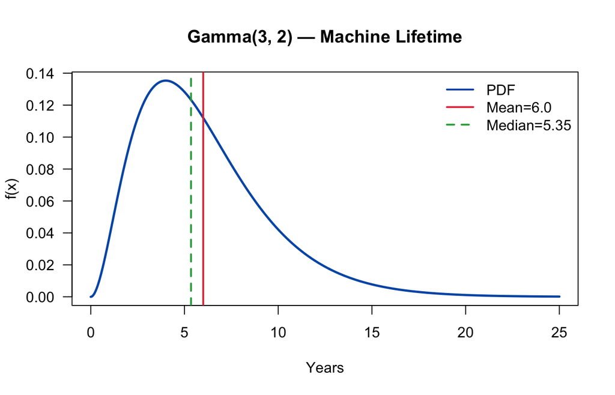

```r
# c. Plot
x <- seq(0, 25, length.out = 500)
plot(x, dgamma(x, k, scale = theta), type = "l",
     lwd = 2.5, col = "#0059b3",
     main = "Gamma(3, 2) — Machine Lifetime",
     xlab = "Years", ylab = "f(x)", las = 1)
abline(v = k * theta, col = "#e63946", lty = 1, lwd = 2)   # mean
abline(v = med,       col = "#28a745", lty = 2, lwd = 2)   # median
legend("topright",
       legend = c("PDF", sprintf("Mean=%.1f", k*theta),
                  sprintf("Median=%.2f", med)),
       col = c("#0059b3","#e63946","#28a745"),
       lty = c(1,1,2), lwd = 2, bty = "n")
```

# Discrete Distributions

## 5. Discrete Uniform Distribution

Each integer in $\{a, a+1, \ldots, b\}$ is equally likely.

$$P(X = x) = \frac{1}{b-a+1}, \quad x = a,
a+1, \ldots, b$$

**Mean:** $\dfrac{a+b}{2}$ **Variance:** $\dfrac{(b-a+1)^2 - 1}{12}$

### Function: Plot Discrete Uniform PMF and CDF

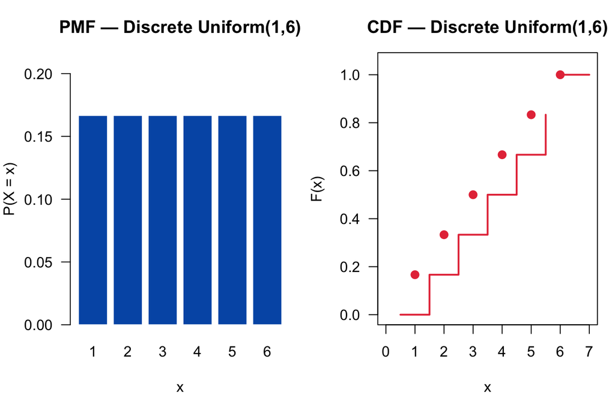

```r
# --------------------------------------------------
# plot_disc_uniform(a, b)
#   Bar chart of PMF and step-function CDF.
# --------------------------------------------------
plot_disc_uniform <- function(a = 1, b = 6) {
  x   <- a:b
  pmf <- rep(1 / (b - a + 1), length(x))
  cdf <- cumsum(pmf)

  par(mfrow = c(1, 2), mar = c(4, 4, 3, 1))

  barplot(pmf, names.arg = x, col = "#0059b3", border = "white",
          main = sprintf("PMF — Discrete Uniform(%d,%d)", a, b),
          xlab = "x", ylab = "P(X = x)", ylim = c(0, max(pmf) * 1.3),
          las = 1)

  plot(x - 0.5, c(0, cdf[-length(cdf)]), type = "s", lwd = 2,
       col = "#e63946", xlim = c(a - 1, b + 1), ylim = c(0, 1.05),
       main = sprintf("CDF — Discrete Uniform(%d,%d)", a, b),
       xlab = "x", ylab = "F(x)", las = 1)
  lines(c(tail(x,1), tail(x,1)+1), c(1,1), col = "#e63946", lwd = 2)
  points(x, cdf, pch = 19, col = "#e63946", cex = 1.2)

  par(mfrow = c(1, 1))
}

plot_disc_uniform(1, 6)    # die
```

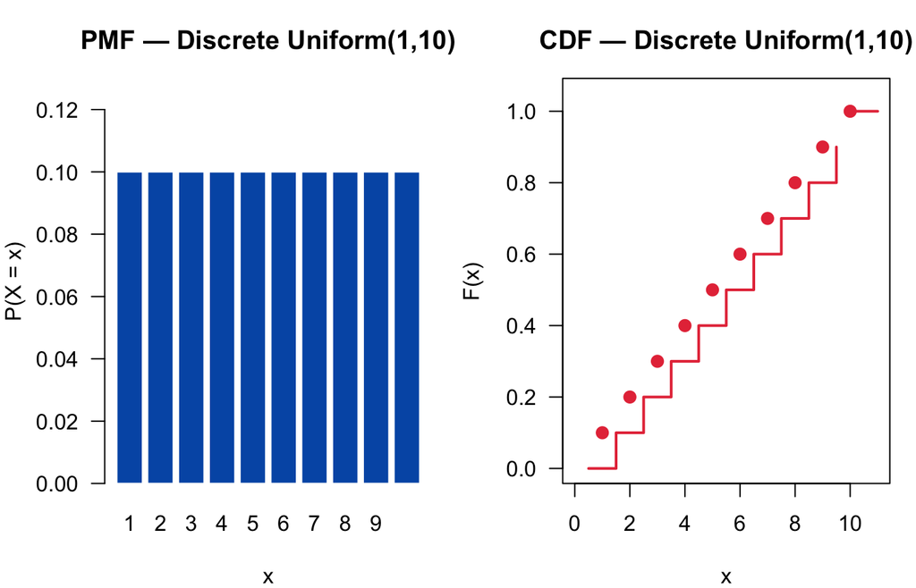

```r
plot_disc_uniform(1, 10)   # uniform draw 1-10
```

### Function: Simulate Die Rolls

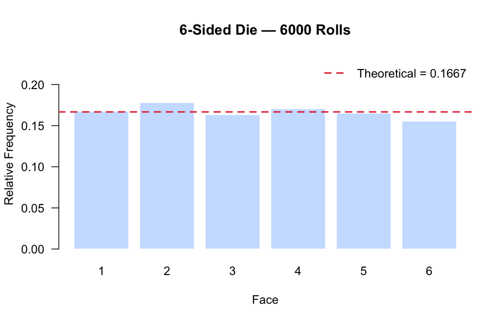

```r
# --------------------------------------------------
# simulate_die(sides, n, seed)
#   Rolls an s-sided die n times; checks uniformity.
# --------------------------------------------------
simulate_die <- function(sides = 6, n = 6000, seed = 42) {
  set.seed(seed)
  rolls <- sample(1:sides, n, replace = TRUE)
  freq  <- table(rolls) / n
  theory <- 1 / sides

  bp <- barplot(freq, col = "#cce0ff", border = "white",
                main = sprintf("%d-Sided Die — %d Rolls", sides, n),
                xlab = "Face", ylab = "Relative Frequency",
                ylim = c(0, max(freq) * 1.3), las = 1)
  abline(h = theory, col = "#e63946", lty = 2, lwd = 2)
  legend("topright",
         legend = sprintf("Theoretical = %.4f", theory),
         col = "#e63946", lty = 2, lwd = 2, bty = "n")

  invisible(freq)
}

simulate_die(6,  6000)
```

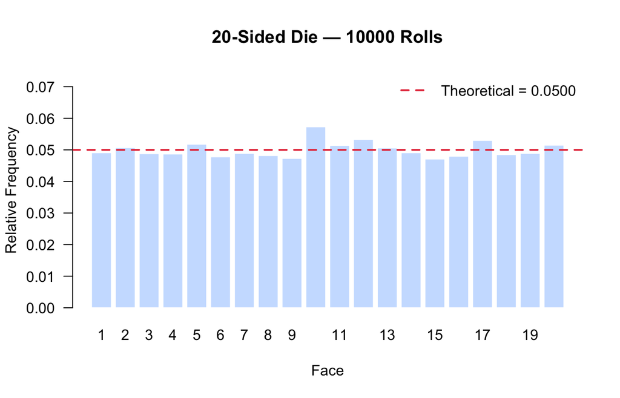

```r
simulate_die(20, 10000)
```

**Question DU-1:** Two fair dice are rolled. Define X = sum of the two dice.

1. Compute the theoretical PMF of X (X can be 2, 3, …, 12).
2. Simulate 100,000 rolls and compare empirical vs. theoretical frequencies.

```r
# a. Theoretical PMF
outcomes <- outer(1:6, 1:6, "+")
pmf_df   <- as.data.frame(table(as.vector(outcomes)) / 36)
names(pmf_df) <- c("sum", "probability")
pmf_df$probability <- round(as.numeric(as.character(pmf_df$probability)), 4)
print(pmf_df)
```

```
#>    sum probability
#> 1    2      0.0278
#> 2    3      0.0556
#> 3    4      0.0833
#> 4    5      0.1111
#> 5    6      0.1389
#> 6    7      0.1667
#> 7    8      0.1389
#> 8    9      0.1111
#> 9   10      0.0833
#> 10  11      0.0556
#> 11  12      0.0278
```

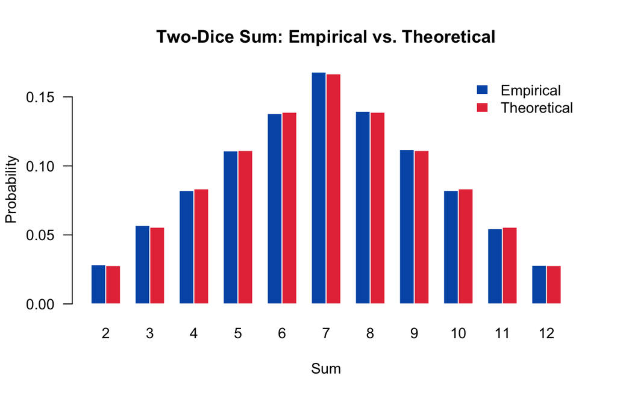

```r
# b. Simulation
set.seed(361)
n      <- 100000
sums   <- sample(1:6, n, replace=TRUE) + sample(1:6, n, replace=TRUE)
emp    <- table(sums) / n
theory <- table(outcomes) / 36

barplot(rbind(emp, theory[names(emp)]),
        beside = TRUE,
        col    = c("#0059b3", "#e63946"),
        border = "white",
        main   = "Two-Dice Sum: Empirical vs. Theoretical",
        xlab   = "Sum", ylab = "Probability", las = 1)
legend("topright", legend = c("Empirical","Theoretical"),
       fill = c("#0059b3","#e63946"), border=NA, bty="n")
```

## 6. Poisson Distribution Poisson(λ)

Models the number of events in a fixed interval when events occur at a constant rate λ.

$$P(X = x) = \frac{\lambda^x
e^{-\lambda}}{x!}, \quad x = 0, 1, 2, \ldots$$

**Mean = Variance = λ**

### Function: Plot Poisson PMF and CDF

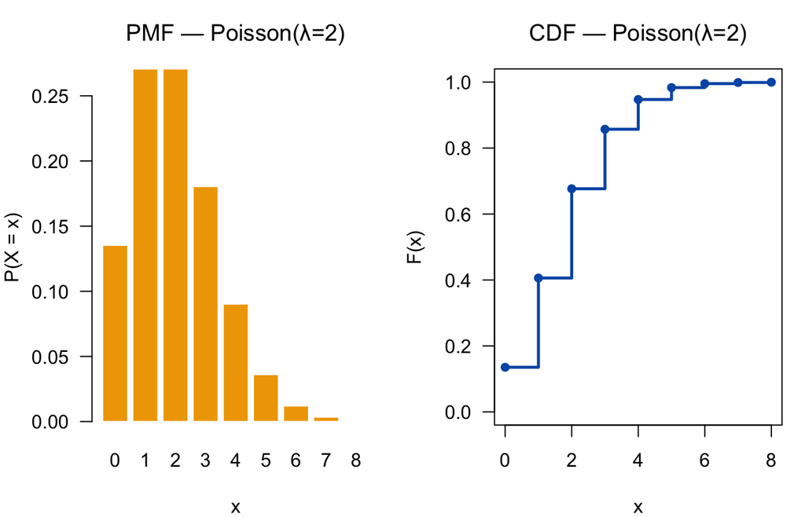

```r
# --------------------------------------------------
# plot_poisson(lambda)
#   PMF bar chart and staircase CDF for Poisson(λ).
# --------------------------------------------------
plot_poisson <- function(lambda = 4) {
  x_max <- qpois(0.9995, lambda)
  x     <- 0:x_max
  pmf   <- dpois(x, lambda)
  cdf   <- ppois(x, lambda)

  par(mfrow = c(1, 2), mar = c(4, 4, 3, 1))

  bp <- barplot(pmf, names.arg = x, col = "#f0a500", border = "white",
                main = bquote("PMF — Poisson(λ=" * .(lambda) * ")"),
                xlab = "x", ylab = "P(X = x)", las = 1)

  plot(x, cdf, type = "s", lwd = 2.5, col = "#0059b3",
       main = bquote("CDF — Poisson(λ=" * .(lambda) * ")"),
       xlab = "x", ylab = "F(x)", ylim = c(0, 1), las = 1)
  points(x, cdf, pch = 19, col = "#0059b3", cex = 0.9)

  par(mfrow = c(1, 1))
}

plot_poisson(2)
```

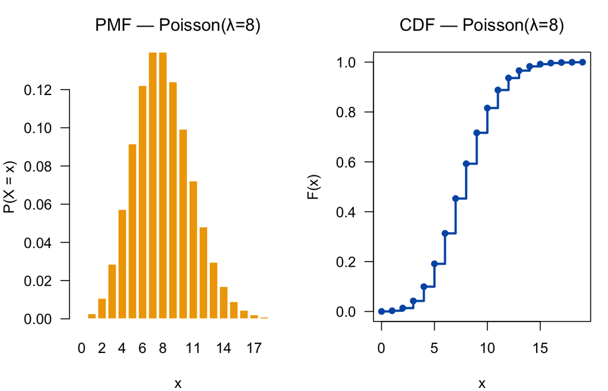

```r
plot_poisson(8)
```

### Function: Compare Poisson Rates

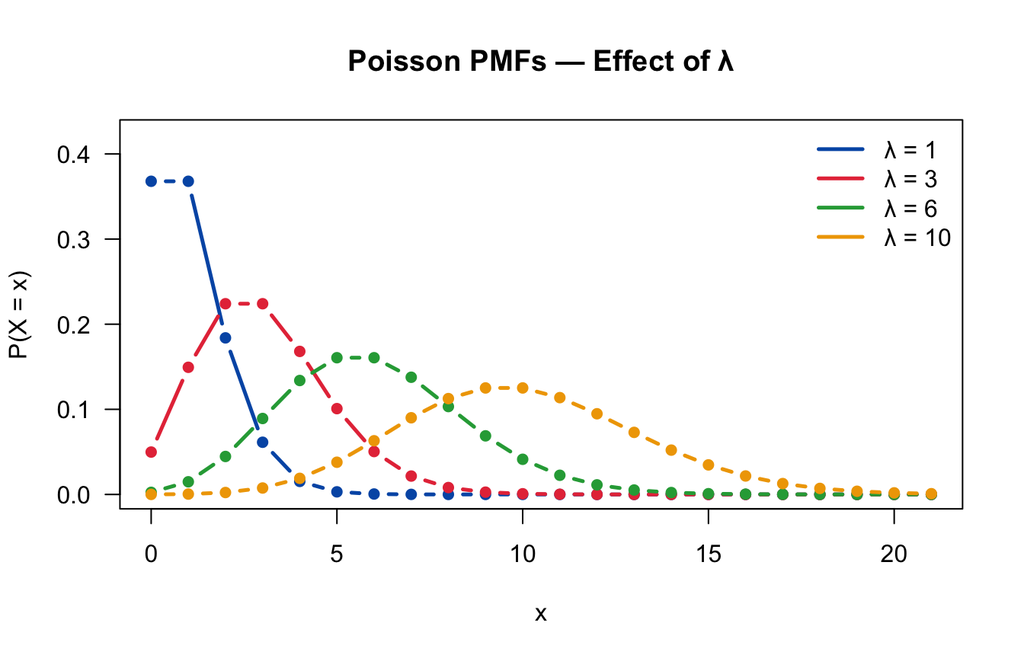

```r
# --------------------------------------------------
# compare_poisson(lambdas)
#   Overlays multiple Poisson PMFs for comparison.
# --------------------------------------------------
compare_poisson <- function(lambdas = c(1, 3, 6, 10)) {
  colors  <- c("#0059b3","#e63946","#28a745","#f0a500","#8e44ad")
  x_max   <- qpois(0.999, max(lambdas))
  x       <- 0:x_max

  y_max <- max(sapply(lambdas, function(l) max(dpois(x, l))))

  plot(x, rep(0, length(x)), type = "n",
       ylim = c(0, y_max * 1.15),
       main = "Poisson PMFs — Effect of λ",
       xlab = "x", ylab = "P(X = x)", las = 1)

  for (i in seq_along(lambdas)) {
    pmf <- dpois(x, lambdas[i])
    lines(x, pmf, col = colors[i], lwd = 2.5, type = "b", pch = 19, cex = 0.7)
  }

  legend("topright",
         legend = paste0("λ = ", lambdas),
         col = colors[seq_along(lambdas)],
         lwd = 2.5, bty = "n")
}

compare_poisson(c(1, 3, 6, 10))
```

**Question P-1:** A hospital emergency room receives an average of 6 patients per hour.

1. What is the probability of receiving **exactly 4 patients** in an hour?
2. What is the probability of receiving **at most 3 patients**?
3. What is the probability of receiving **more than 10 patients**?
4. Simulate 10,000 one-hour periods and compare to theory.

```r
lambda <- 6

# a. P(X = 4)
cat(sprintf("a. P(X = 4)    = %.4f\n", dpois(4, lambda)))
```

```
#> a. P(X = 4)    = 0.1339
```

```r
# b. P(X <= 3)
cat(sprintf("b. P(X <= 3)   = %.4f\n", ppois(3, lambda)))
```

```
#> b. P(X <= 3)   = 0.1512
```

```r
# c. P(X > 10)
cat(sprintf("c. P(X > 10)   = %.4f\n", 1 - ppois(10, lambda)))
```

```
#> c. P(X > 10)   = 0.0426
```

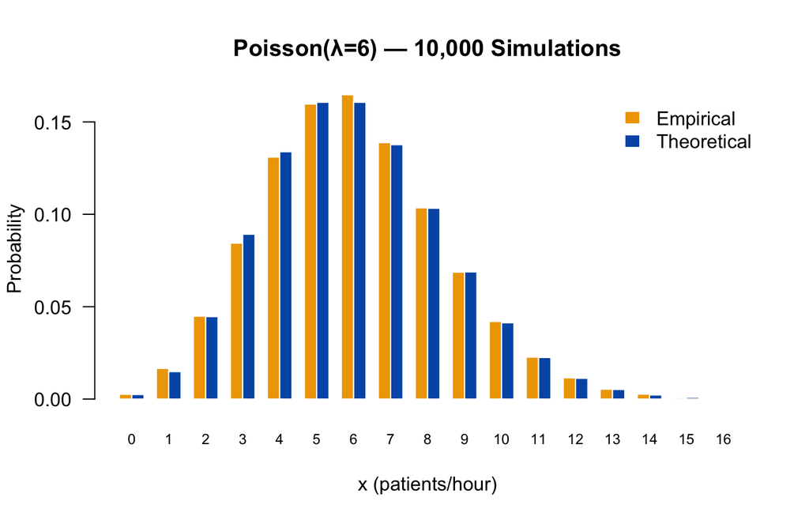

```r
# d. Simulation
set.seed(361)
counts  <- rpois(10000, lambda)
x_range <- 0:max(counts)
emp     <- table(factor(counts, levels = x_range)) / 10000
theory  <- dpois(x_range, lambda)

barplot(rbind(emp, theory),
        beside = TRUE,
        col    = c("#f0a500","#0059b3"),
        border = "white",
        main   = bquote("Poisson(λ=6) — 10,000 Simulations"),
        xlab   = "x (patients/hour)", ylab = "Probability",
        names.arg = x_range, las = 1, cex.names = 0.75)
legend("topright", legend = c("Empirical","Theoretical"),
       fill = c("#f0a500","#0059b3"), border=NA, bty="n")
```

## 7. Binomial Distribution Bin(n, p)

Counts successes in $n$ **independent** Bernoulli trials each with success probability $p$.

$$P(X = x) = \binom{n}{x} p^x (1-p)^{n-x},
\quad x = 0, 1, \ldots, n$$

**Mean:** $np$ **Variance:** $np(1-p)$

### Function: Plot Binomial PMF and CDF

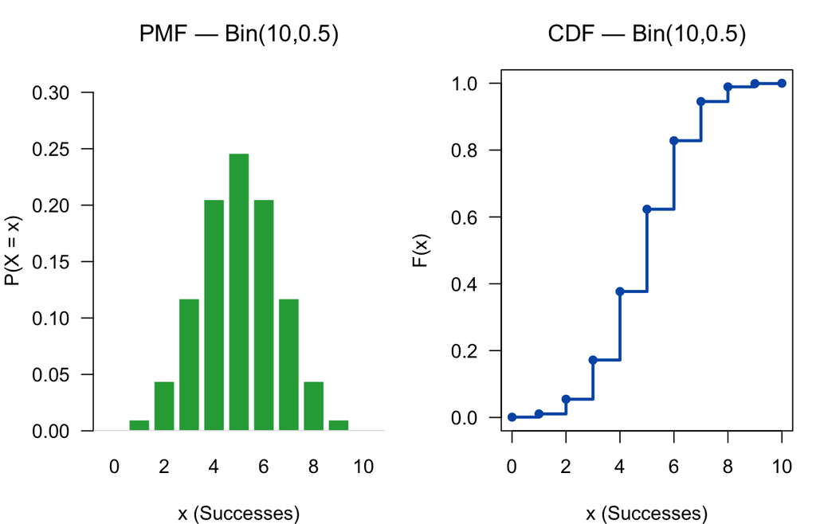

```r
# --------------------------------------------------
# plot_binomial(n, p)
#   PMF and CDF for Bin(n, p).
# --------------------------------------------------
plot_binomial <- function(n = 10, p = 0.5) {
  x   <- 0:n
  pmf <- dbinom(x, n, p)
  cdf <- pbinom(x, n, p)

  par(mfrow = c(1, 2), mar = c(4, 4, 3, 1))

  barplot(pmf, names.arg = x, col = "#28a745", border = "white",
          main = bquote("PMF — Bin(" * .(n) * "," * .(p) * ")"),
          xlab = "x (Successes)", ylab = "P(X = x)",
          ylim = c(0, max(pmf) * 1.3), las = 1)
  abline(h = 0, col = "grey80")

  plot(x, cdf, type = "s", lwd = 2.5, col = "#0059b3",
       main = bquote("CDF — Bin(" * .(n) * "," * .(p) * ")"),
       xlab = "x (Successes)", ylab = "F(x)", ylim = c(0, 1), las = 1)
  points(x, cdf, pch = 19, col = "#0059b3", cex = 0.9)

  par(mfrow = c(1, 1))
}

plot_binomial(10, 0.5)
```

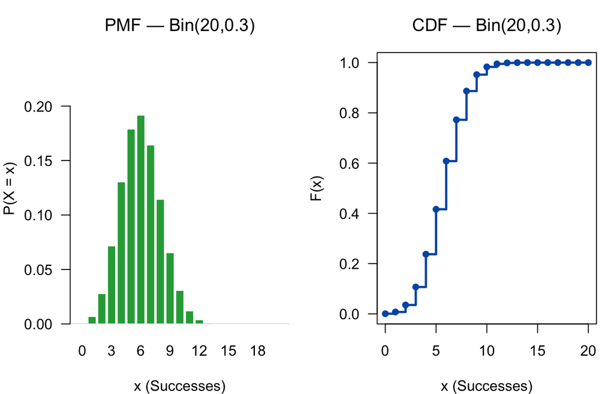

```r
plot_binomial(20, 0.3)
```

### Function: Compare Binomial Shapes

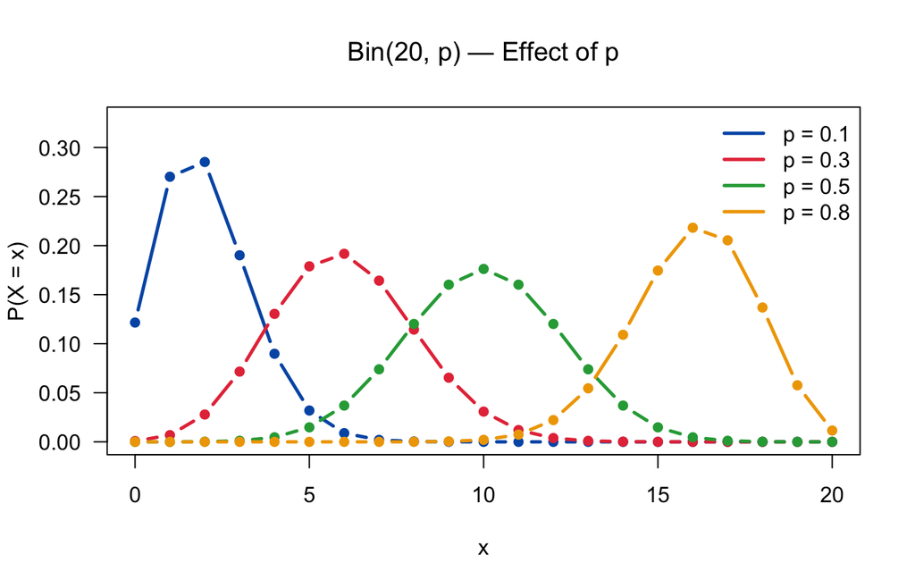

```r
# --------------------------------------------------
# compare_binomials(n, probs)
#   Shows effect of p on Bin(n, p) PMF.
# --------------------------------------------------
compare_binomials <- function(n = 20, probs = c(0.2, 0.5, 0.7, 0.9)) {
  colors <- c("#0059b3","#e63946","#28a745","#f0a500")
  x      <- 0:n
  y_max  <- max(sapply(probs, function(p) max(dbinom(x, n, p))))

  plot(x, rep(0, n+1), type = "n", ylim = c(0, y_max*1.15),
       main = bquote("Bin(" * .(n) * ", p) — Effect of p"),
       xlab = "x", ylab = "P(X = x)", las = 1)
  for (i in seq_along(probs)) {
    lines(x, dbinom(x, n, probs[i]),
          type = "b", col = colors[i], lwd = 2.5, pch = 19, cex = 0.7)
  }
  legend("topright",
         legend = paste0("p = ", probs),
         col = colors[seq_along(probs)], lwd = 2.5, bty = "n")
}

compare_binomials(20, c(0.1, 0.3, 0.5, 0.8))
```

**Question B-1:** A student guesses answers on a 15-question true/false exam (p = 0.5).

1. What is the probability of getting **exactly 10 correct**?
2. What is the probability of **passing** (≥ 8 correct)?
3. How many questions should she expect to get right?
4. Plot the full PMF and mark the passing threshold.

```r
n <- 15; p <- 0.5

# a. P(X = 10)
cat(sprintf("a. P(X = 10) = %.4f\n", dbinom(10, n, p)))
```

```
#> a. P(X = 10) = 0.0916
```

```r
# b. P(X >= 8)
cat(sprintf("b. P(X >= 8) = %.4f\n", 1 - pbinom(7, n, p)))
```

```
#> b. P(X >= 8) = 0.5000
```

```r
# c. Expected value
cat(sprintf("c. E[X]      = %.1f correct answers\n", n * p))
```

```
#> c. E[X]      = 7.5 correct answers
```

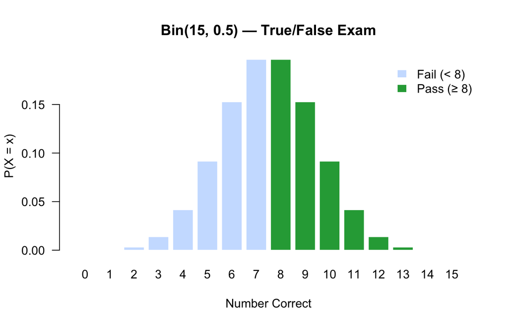

```r
# d. PMF plot with passing threshold
x   <- 0:n
pmf <- dbinom(x, n, p)
cols <- ifelse(x >= 8, "#28a745", "#cce0ff")

barplot(pmf, names.arg = x, col = cols, border = "white",
        main = "Bin(15, 0.5) — True/False Exam",
        xlab = "Number Correct", ylab = "P(X = x)", las = 1)
legend("topright",
       legend = c("Fail (< 8)", "Pass (≥ 8)"),
       fill   = c("#cce0ff","#28a745"),
       border = NA, bty = "n")
```

**Question B-2:** Normal approximation to the Binomial.

For large $n$, $\text{Bin}(n, p) \approx N(np, \, np(1-p))$. Demonstrate this visually for Bin(100, 0.4).

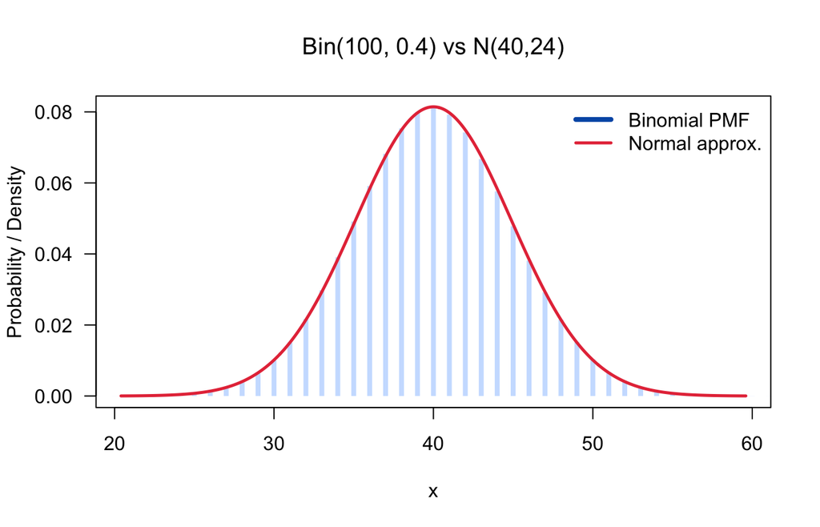

```r
n <- 100; p <- 0.4
mu    <- n * p
sigma <- sqrt(n * p * (1 - p))

x_disc <- 0:n
x_cont <- seq(mu - 4*sigma, mu + 4*sigma, length.out = 500)

plot(x_disc, dbinom(x_disc, n, p), type = "h",
     col = "#cce0ff", lwd = 4, lend = 1,
     main = bquote("Bin(100, 0.4) vs N(" * .(mu) * "," * .(round(sigma^2,1)) * ")"),
     xlab = "x", ylab = "Probability / Density",
     xlim = c(mu - 4*sigma, mu + 4*sigma), las = 1)
lines(x_cont, dnorm(x_cont, mu, sigma), col = "#e63946", lwd = 2.5)
legend("topright",
       legend = c("Binomial PMF", "Normal approx."),
       col = c("#0059b3","#e63946"), lwd = c(4,2.5),
       lty = 1, bty = "n")
```

# Comprehensive Distribution Reference Table

Summary of Key Probability Distributions in R

| Distribution | Type | R_Functions | Mean | Variance |
| --- | --- | --- | --- | --- |
| Uniform U(a,b) | Continuous | dunif/punif/qunif/runif | (a+b)/2 | (b-a)²/12 |
| Normal N(μ,σ²) | Continuous | dnorm/pnorm/qnorm/rnorm | μ | σ² |
| Exponential Exp(λ) | Continuous | dexp/pexp/qexp/rexp | 1/λ | 1/λ² |
| Gamma Γ(k,θ) | Continuous | dgamma/pgamma/qgamma/rgamma | kθ | kθ² |
| Disc. Uniform | Discrete | sample() or manual | (a+b)/2 | ((b-a+1)²-1)/12 |
| Poisson Poi(λ) | Discrete | dpois/ppois/qpois/rpois | λ | λ |
| Binomial Bin(n,p) | Discrete | dbinom/pbinom/qbinom/rbinom | np | np(1-p) |

# Practice Exercises

**Exercise 1 — Uniform:** The time it takes a bus to arrive is uniformly distributed between 0 and 20 minutes. Write a function that computes P(a ≤ X ≤ b) both theoretically and by simulation with n draws.

**Exercise 2 — Normal:** IQ scores are distributed as N(100, 225). Write a function `iq_analysis(lo, hi)` that returns P(lo < X < hi), the corresponding z-scores, and a shaded area plot.

**Exercise 3 — Exponential:** Write a function `exp_quantiles(lambda, probs)` that returns a table of theoretical quantiles and verifies them empirically using a sample of n = 50,000.

**Exercise 4 — Poisson:** A factory has on average 2 defects per 100 metres of fabric. Write a function that computes the probability of finding at most k defects in L metres of fabric.

**Exercise 5 — Binomial:** A drug is effective in 70% of cases. In a trial of 25 patients, write a function that returns the probability that at least k patients respond, and plots the PMF with that region highlighted.

**Exercise 6 — Gamma vs. Exponential:** Verify algebraically and in R that Gamma(1, 1/λ) is equivalent to Exp(λ) by overlaying their PDFs and comparing sample statistics.

*Office hour: Monday, 13.40-14.30*

*Room No: 234*